# Big Data: Sentiment Analysis

David Verbiest

22/01/2020

# Conclusions

- The data for **Samsung** contains **very few mentions of the brand** Samsung or Galaxy, making the data of little use for sentiment analysis.
- This leads us to believe **something went wrong in the data collection phase**.
- The overall **sentiment for iPhone models is very positive** (The overall ratio positive to negative is over 10 to 1)
- If time doesn’t permit for further investigation of the opinion on the brand Samsung, we **recommend to move ahead with iPhone**. The overwhelming positive sentiment is the main motivation for this recommendation.

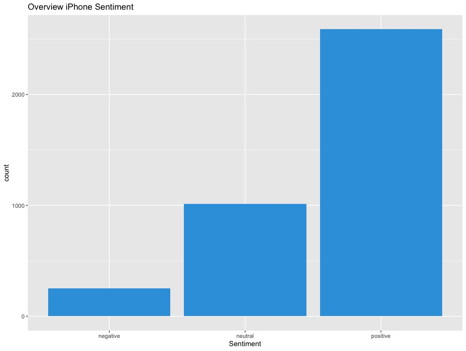

# Recommendations and Next Steps

- If further research isn’t possible, select the iPhone to run the applications.
- Gather new data for Galaxy and check mapper function for the brand Galaxy
- Try additional machine learning methods
- Test dictionnary based sentiment analysis methods instead of machine learning methods
- Test different hyperparameters values unique for each machine learning model.

# Analysis

## Introduction

- Helio is working with a **government health agency** to create a suite of smart phone **medical apps** for use by aid workers in developing countries.
- **One phone** needs to be selected to **run the application**
- A short list of devices that are all capable of executing the app suite’s functions werer provided
- Conduct a broad-based web **sentiment analysis** to gain insight into the attitudes toward the devices

## Load data

```r
pacman::p_load(pacman, rstudioapi, caret, doParallel, corrplot, tidyverse)
```

```r
# Import data
data_iphone <- read.csv(file = "/Users/davidverbiest/google_drive/data_science/ubiqum/m4/t3/data/iphone_smallmatrix_labeled_8d.csv")
data_galaxy <- read.csv(file = "/Users/davidverbiest/google_drive/data_science/ubiqum/m4/t3/data/galaxy_smallmatrix_labeled_8d.csv")
```

## Initial exploration

| iphone | samsunggalaxy | sonyxperia | nokialumina | htcphone | ios | googleandroid | iphonecampos | samsungcampos | sonycampos | nokiacampos | htccampos | iphonecamneg | samsungcamneg | sonycamneg | nokiacamneg | htccamneg | iphonecamunc | samsungcamunc | sonycamunc | nokiacamunc | htccamunc | iphonedispos | samsungdispos | sonydispos | nokiadispos | htcdispos | iphonedisneg | samsungdisneg | sonydisneg | … |
| --- | --- | --- | --- | --- | --- | --- | --- | --- | --- | --- | --- | --- | --- | --- | --- | --- | --- | --- | --- | --- | --- | --- | --- | --- | --- | --- | --- | --- | --- | --- |
| 1 | 0 | 0 | 0 | 0 | 0 | 0 | 0 | 0 | 0 | 0 | 0 | 0 | 0 | 0 | 0 | 0 | 0 | 0 | 0 | 0 | 0 | 0 | 0 | 0 | 0 | 0 | 0 | 0 | 0 | … |
| 1 | 0 | 0 | 0 | 0 | 0 | 0 | 0 | 0 | 0 | 0 | 0 | 0 | 0 | 0 | 0 | 0 | 0 | 0 | 0 | 0 | 0 | 0 | 0 | 0 | 0 | 0 | 0 | 0 | 0 | … |
| 1 | 0 | 0 | 0 | 0 | 0 | 0 | 0 | 0 | 0 | 0 | 0 | 0 | 0 | 0 | 0 | 0 | 0 | 0 | 0 | 0 | 0 | 0 | 0 | 0 | 0 | 0 | 0 | 0 | 0 | … |
| 1 | 0 | 0 | 0 | 0 | 0 | 0 | 0 | 0 | 0 | 0 | 0 | 0 | 0 | 0 | 0 | 0 | 0 | 0 | 0 | 0 | 0 | 0 | 0 | 0 | 0 | 0 | 0 | 0 | 0 | … |
| 1 | 0 | 0 | 0 | 0 | 0 | 0 | 0 | 0 | 0 | 0 | 0 | 0 | 0 | 0 | 0 | 0 | 0 | 0 | 0 | 0 | 0 | 0 | 0 | 0 | 0 | 0 | 0 | 0 | 0 | … |
| 41 | 0 | 0 | 0 | 0 | 6 | 0 | 1 | 0 | 0 | 0 | 0 | 3 | 0 | 0 | 0 | 0 | 7 | 0 | 0 | 0 | 0 | 1 | 0 | 0 | 0 | 0 | 3 | 0 | 0 | … |

| iphone | samsunggalaxy | sonyxperia | nokialumina | htcphone | ios | googleandroid | iphonecampos | samsungcampos | sonycampos | nokiacampos | htccampos | iphonecamneg | samsungcamneg | sonycamneg | nokiacamneg | htccamneg | iphonecamunc | samsungcamunc | sonycamunc | nokiacamunc | htccamunc | iphonedispos | samsungdispos | sonydispos | nokiadispos | htcdispos | iphonedisneg | samsungdisneg | sonydisneg | … |
| --- | --- | --- | --- | --- | --- | --- | --- | --- | --- | --- | --- | --- | --- | --- | --- | --- | --- | --- | --- | --- | --- | --- | --- | --- | --- | --- | --- | --- | --- | --- |
| 1 | 0 | 0 | 0 | 0 | 0 | 0 | 0 | 0 | 0 | 0 | 0 | 0 | 0 | 0 | 0 | 0 | 0 | 0 | 0 | 0 | 0 | 0 | 0 | 0 | 0 | 0 | 0 | 0 | 0 | … |
| 1 | 0 | 0 | 0 | 0 | 0 | 0 | 0 | 0 | 0 | 0 | 0 | 0 | 0 | 0 | 0 | 0 | 0 | 0 | 0 | 0 | 0 | 1 | 0 | 0 | 0 | 0 | 1 | 0 | 0 | … |
| 1 | 1 | 0 | 0 | 0 | 0 | 0 | 1 | 1 | 0 | 0 | 0 | 0 | 0 | 0 | 0 | 0 | 0 | 0 | 0 | 0 | 0 | 0 | 0 | 0 | 0 | 0 | 0 | 0 | 0 | … |
| 0 | 0 | 0 | 0 | 1 | 0 | 0 | 0 | 0 | 0 | 0 | 0 | 0 | 0 | 0 | 0 | 0 | 0 | 0 | 0 | 0 | 0 | 0 | 0 | 0 | 0 | 1 | 0 | 0 | 0 | … |
| 1 | 0 | 0 | 0 | 0 | 0 | 0 | 0 | 0 | 0 | 0 | 0 | 0 | 0 | 0 | 0 | 0 | 0 | 0 | 0 | 0 | 0 | 0 | 0 | 0 | 0 | 0 | 0 | 0 | 0 | … |
| 2 | 0 | 0 | 0 | 0 | 0 | 0 | 1 | 0 | 0 | 0 | 0 | 0 | 0 | 0 | 0 | 0 | 0 | 0 | 0 | 0 | 0 | 0 | 0 | 0 | 0 | 0 | 0 | 0 | 0 | … |

- We have many features available for analysis
- We notice that the both data sets have similar headers.
- Each column represent the frequency of a word or a combination of words in the header. (For me a more detailed description of each variable please see file “Helio_Sentiment_Analysis_Matrix_Detail.csv” in the data folder)

Let’s take a look at the number of times each brand was mentioned for the respective websites

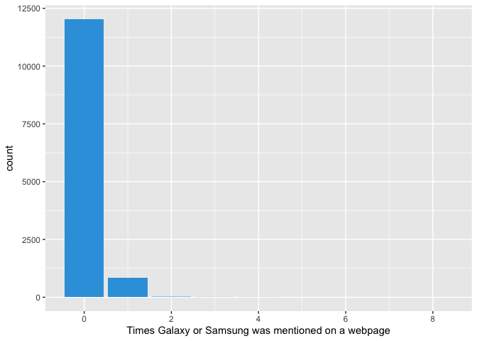

We see that for most intances there are almost no mentions of Samsung or galaxy phones on the website. Pages that only have one or two mentions of the brand could just be noise i.e. the person mentions they saw a great Samsung/iphone commercial. This leads us to believe that these webpages do not really convey much information about the true sentiment of this brand/phone (Or that the mapper function doesn’t). Therefore we will not continue with this data set. It is recommended to gather the data again and include more webpages that contain more Samsung mentions or take a closer look at the mapper function and look for any potential errors.

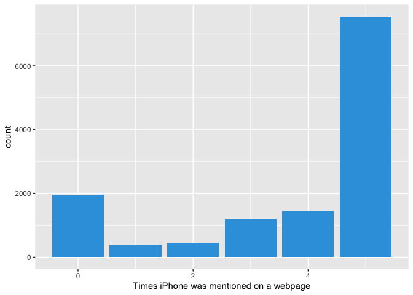

For the same reason we drop the rows that have less than 3 iphone mentions

When we check for NA’s or NULL we see that there are none in the data set

```r
sum(is.na(data_iphone))
```

```
## [1] 0
```

```r
sum(is.null(data_iphone))
```

```
## [1] 0
```

## Preprocessing and feature selection

We recode the sentiment classes to negative (0, 1), neutral (2, 3), and positve (4, 5)

```r
# Recode sentiment
data_iphone[data_iphone$iphonesentiment %in% c(4, 5), ]$iphonesentiment <- "positive"
data_iphone[data_iphone$iphonesentiment %in% c(0, 1), ]$iphonesentiment <- "negative"
data_iphone[data_iphone$iphonesentiment %in% c(2, 3), ]$iphonesentiment <- "neutral"

# Convert to factor
data_iphone$iphonesentiment <- as.factor(data_iphone$iphonesentiment)
```

Let’s take a closer look at the distribution of the classes

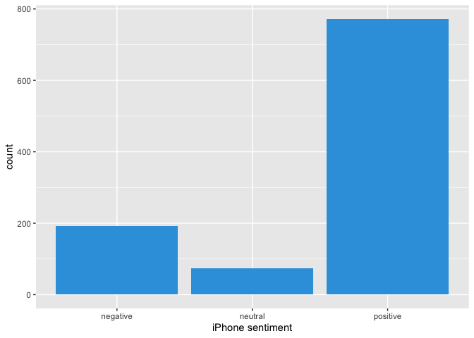

We observe a clear class imbalance. To deal with class imbalance we use a method called upSample from the CARET package. This method will create artificial data from the minorty classes until the classes are balanced. We can see the result of upSample below.

```r
# Upsample and downsample
data_iphone <- upSample(x = data_iphone[, -ncol(data_iphone)], y = data_iphone$iphonesentiment)
```

```r
# the upSample function automaticaly converts the colnames of the label to "Class", rename "Class" to "iphonesentiment"
colnames(data_iphone)[59] <- "iphonesentiment"
```

| Var1 | Freq |
| --- | --- |
| negative | 772 |
| neutral | 772 |
| positive | 772 |

In the next step we will select a subset of features that will be included in our model. We looked at the following methods:

- Eliminate near zero variance features
- Use recursive feature elimantion (RFE)

We found the best results for RFE, which can be found with the following code

```r
# Let's sample the data before using RFE
iphoneSample <- data_iphone[sample(1:nrow(data_iphone), 1000, replace=FALSE),]

# Set up rfeControl with randomforest, repeated cross validation and no updates
ctrl <- rfeControl(functions = rfFuncs,
                   method = "repeatedcv",
                   repeats = 5,
                   verbose = FALSE)

# Use rfe and omit the response variable (attribute 59 iphonesentiment)
rfeResults <- rfe(iphoneSample[,1:58],
                  iphoneSample$iphonesentiment,
                  sizes=(1:58),
                  rfeControl=ctrl)
```

|  | Variables | Accuracy | Kappa | AccuracySD | KappaSD |
| --- | --- | --- | --- | --- | --- |
| 39 | 39 | 0.7210460 | 0.5788971 | 0.0363071 | 0.0554147 |
| 38 | 38 | 0.7210410 | 0.5789139 | 0.0347566 | 0.0530045 |
| 37 | 37 | 0.7210360 | 0.5789156 | 0.0350862 | 0.0534680 |
| 36 | 36 | 0.7200559 | 0.5774488 | 0.0371156 | 0.0564987 |
| 27 | 27 | 0.7170257 | 0.5728233 | 0.0374541 | 0.0571113 |
| 40 | 40 | 0.7170257 | 0.5728307 | 0.0349078 | 0.0531336 |

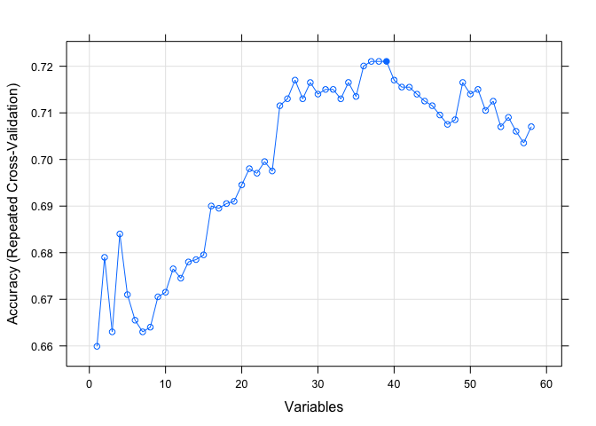

```r
# Plot results
plot(rfeResults, type=c("g", "o"))
```

Create new data set with rfe recommended features

```r
iphoneRFE <- data_iphone[,predictors(rfeResults)]

# add the dependent variable to iphoneRFE
iphoneRFE$iphonesentiment <- data_iphone$iphonesentiment
```

The data frame we will be modeling with:

```r
knitr::kable(str(iphoneRFE))
```

[output not shown]

Rename iphoneRGE as df for modeling purposes

```r
df <- iphoneRFE
```

## Modeling

```r
# Create models and predict on test
models = c("rf", "knn", "svmRadial")
models_fitted <-  list()
models_results <- list()
aggr_confusion_matrix <- list()

# Set-up resampling method
fit_control <-  trainControl(method = "repeatedcv",
                             number = 5,
                             repeats = 3)

for (i in models) {

  model <- train(iphonesentiment ~ .,
                 data = df,
                 preProc = c("center", "scale"),
                 method = i,
                 trControl = fit_control,
                 metric = "Accuracy")

  models_fitted[i] <- list(model)

  models_results[i] <- list(model$results)
}
```

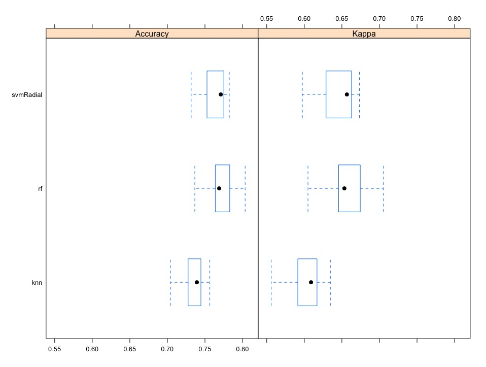

We fit a random forest on all the data and will use this model for making our final predictions

```r
final_model <- train(iphonesentiment ~ .,
               data = df,
               preProc = c("center", "scale"),
               method = "rf",
               tuneLength = 5)
```

## Predictions

We will make predictions on the results of the webcrawl. All together over 80.000 webpages were crawled.

We use the fitted model (random forest) from the modeling section to predict the sentiment of the relevant webpages. This yields the following results.

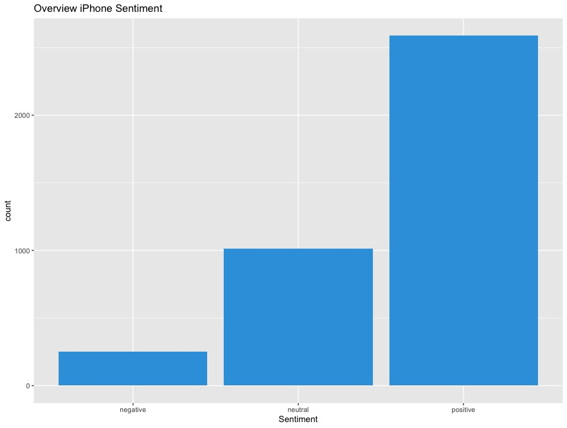

We can see that the overall results for iphone are quite positve. For every negative review there are more than 10 positive reviews. Therefore we recommend to move ahead with the iphone. If time permits we should perform the same exercise for Samsung. As mentioned earlier, the quality of the Samsung data is not good enough to make any reliable predictions. Before performing the same analysis for Samsung, these issues need to be resolved.

# R code used for analysis

```r
#-------------------------------------Set-up environment----------------------------------------#

# Install packages
pacman::p_load(pacman, rstudioapi, caret, doParallel, corrplot, tidyverse)

# Set working directory
path <- getActiveDocumentContext()$path
setwd(dirname(path))

# Set random seed
set.seed(123)

# Set up parallel processing

# Find how many cores are on your machine
detectCores()

# Create Cluster with desired number of cores. Don't use them all! Your computer is running other processes.
clusters <-  makeCluster(2)

# Register cluster
registerDoParallel(clusters)

# Confirm how many cores are now "assigned" to R and RStudio
getDoParWorkers() # Result 2


#------------------------------------------Read data-------------------------------------------#

# Import data
data_iphone <- read.csv(file = "./data/iphone_smallmatrix_labeled_8d.csv")
data_galaxy <- read.csv(file = "./data/galaxy_smallmatrix_labeled_8d.csv")

#-------------------------------------Initial Exploration--------------------------------------#

# Initial exploration
str(data_iphone)
summary(data_iphone)
head(data_iphone)

str(data_galaxy)
summary(data_galaxy)
head(data_galaxy)

# Make sentiment factor
#data_iphone$iphonesentiment = as.factor(data_iphone$iphonesentiment)
#data_galaxy$iphonesentiment = as.factor(data_iphone$galaxysentiment)

# Check the frequency of and galaxy data
ggplot(data = data_galaxy, aes(x = data_galaxy$samsunggalaxy)) +
  geom_histogram(stat = "count")

# We see that for most intances there are almost no mentions of
# phones. This leads us to believe that
# these webpages do not really convey much information about the true sentiment of this brand/phone.
# Therefore we will not continue with this data set. It is recommended gather the data again and
# include more webpages that

# For the same reason we drop the rows that have less than 3 iphone mentions
data_iphone <- data_iphone[data_iphone$iphone > 2,]

# Check the dependant variable
ggplot(data = data_iphone, aes(x = iphonesentiment)) +
  geom_histogram(stat = "count")

# check for missing addresses
sum(is.na(data_iphone))
sum(is.na(data_galaxy))

# check for missing addresses
sum(is.null(data_iphone))
sum(is.null(data_galaxy))

#--------------------------------Preprocessing adn feature selection--------------------------------#

# Drop lines with less than reviews

# Increase max print
options(max.print=1000000)

# Check correlations
corr_galaxy <- cor(data_galaxy)
corr_iphone <- cor(data_iphone)
corrplot(corr_galaxy)

# Create a new data set and remove features highly correlated with the dependant
# iphoneCOR$featureToRemove <- NULL

# Recode sentiment
data_iphone[data_iphone$iphonesentiment %in% c(4, 5), ]$iphonesentiment <- "positive"
data_iphone[data_iphone$iphonesentiment %in% c(0, 1), ]$iphonesentiment <- "negative"
data_iphone[data_iphone$iphonesentiment %in% c(2, 3), ]$iphonesentiment <- "neutral"

# Convert to factor
data_iphone$iphonesentiment <- as.factor(data_iphone$iphonesentiment)

# Check the results of recoding
ggplot(data = data_iphone, aes(x = iphonesentiment)) +
  geom_histogram(stat = "count")

# Let's check class imbalances
table(data_iphone$iphonesentiment)

# Upsample and downsample
data_iphone <- upSample(x = data_iphone[, -ncol(data_iphone)], y = data_iphone$iphonesentiment)
colnames(data_iphone)[59] <- "iphonesentiment"
table(data_iphone$iphonesentiment)
str(data_iphone)
# iphone data

# NearZeroVar() with saveMetrics = TRUE returns an object containing a table including: frequency ratio,
# percentage unique, zero variance and near zero variance
nzvMetrics <- nearZeroVar(data_iphone, saveMetrics = TRUE)
nzvMetrics

# nearZeroVar() with saveMetrics = FALSE returns an vector
nzv <- nearZeroVar(data_iphone, saveMetrics = FALSE)
nzv


# create a new data set and remove near zero variance features
iphoneNZV <- data_iphone[,-nzv]
str(iphoneNZV)

# Let's sample the data before using RFE
iphoneSample <- data_iphone[sample(1:nrow(data_iphone), 1000, replace=FALSE),]

# Set up rfeControl with randomforest, repeated cross validation and no updates
ctrl <- rfeControl(functions = rfFuncs,
                   method = "repeatedcv",
                   repeats = 2,
                   verbose = FALSE)

# Use rfe and omit the response variable (attribute 59 iphonesentiment)
rfeResults <- rfe(iphoneSample[,1:58],
                  iphoneSample$iphonesentiment,
                  sizes=(1:58),
                  rfeControl=ctrl)

# Get results
rfeResults

# Save results to RData so we can open these in R markdown
save(rfeResults, file="./saved_objects/rfeResults.RData")

# Plot results
plot(rfeResults, type=c("g", "o"))

# create new data set with rfe recommended features
iphoneRFE <- data_iphone[,predictors(rfeResults)]

# add the dependent variable to iphoneRFE
iphoneRFE$iphonesentiment <- data_iphone$iphonesentiment

# Save results to csv so we can open these in R markdown
write.csv(iphoneRFE, file = "/Users/davidverbiest/google_drive/data_science/ubiqum/m4/t3/data/rfeResults.csv")

# review outcome
str(iphoneRFE)

# Rename iphoneRGE as df for modeling
df <- iphoneRFE

#--------------------------------Modeling--------------------------------#

# Create models and predict on test
models = c("rf", "knn", "svmRadial")
models_fitted <-  list()
models_results <- list()
aggr_confusion_matrix <- list()

# Set-up resampling method
fit_control <-  trainControl(method = "repeatedcv",
                             number = 5,
                             repeats = 3)

for (i in models) {

  model <- train(iphonesentiment ~ .,
                 data = df,
                 preProc = c("center", "scale"),
                 method = i,
                 trControl = fit_control,
                 metric = "Accuracy")

  models_fitted[i] <- list(model)

  models_results[i] <- list(model$results)

}

# Check model performance and pick best performing model
resamps <- resamples(models_fitted)
theme1 <- trellis.par.get()
theme1$plot.symbol$col = rgb(.2, .2, .2, .4)
theme1$plot.symbol$pch = 16
theme1$plot.line$col = rgb(1, 0, 0, .7)
theme1$plot.line$lwd <- 2
trellis.par.set(theme1)
bwplot(resamps, layout = c(2, 1))

# Rename iphoneRGE as df for modeling
df <- iphoneRFE

# random forest has te best performance. We train a random forest on all the data
model <- train(iphonesentiment ~ .,
               data = df,
               preProc = c("center", "scale"),
               method = "rf",
               tuneLength = 5)

#--------------------------------Predictions--------------------------------#

# Make predictions on the results of the webcrawl

# Load webscraped data that will be used to estimate sentiment of the data -->
testing <- read.csv(file = "/Users/davidverbiest/google_drive/data_science/ubiqum/m4/t3/data/join_concat_concat_factors.csv")

# Just like mentioned above we will drop the reviews that have less than 3 mentions of the brand
testing <- testing[testing$iphone > 2,]

# Select same features as in training
testing <- testing[,predictors(rfeResults)]

# Check if features are the same for both training and testing
colnames(testing) == colnames(df[,-ncol(df)])

# Use trained model to make predictions
final_pred <-  predict(model, testing)

# Check sentiment
table_final_pred <- table(final_pred)

# Make a bar chart of the sentiment
final_pred <- as.data.frame(final_pred)

ggplot(final_pred, aes(x = final_pred)) +
  geom_bar(fill =  "#33A1DE") +
  xlab("Sentiment") +
  ggtitle("Overview iPhone Sentiment")

# Reset settings for parallel computing
stopCluster(clusters)
```